# Ordinal Logistic Regression: Diabetes Health Status

Analysis of CDC BRFSS 2015 Health Indicators Dataset

Author

Dr Munir

Published

June 2, 2026

# 1 Introduction

This assignment applies **ordinal logistic regression** (proportional odds model) to the CDC Behavioral Risk Factor Surveillance System (BRFSS) 2015 dataset, which contains 253,680 survey responses from US adults.

**Research question:** What sociodemographic, behavioural, and clinical factors are associated with severity of diabetes status (No Diabetes → Pre-diabetes → Diabetes)?

**Outcome variable:** `Diabetes_012` : an ordered three-category variable:

- `0` = No diabetes
- `1` = Pre-diabetes
- `2` = Diabetes

The outcome has a natural ordering. That ordering is what justifies the **proportional odds model (cumulative link model)** here, following Hosmer, Lemeshow & Sturdivant (Chapter 8, *Applied Logistic Regression*, 3rd ed.).

# 2 Data Preparation

## 2.1 Load Libraries

```r
library(tidyverse)
library(ordinal)     # clm() : cumulative link model
library(gtsummary)   # publication-quality tables
library(broom)       # tidy model outputs
library(knitr)       # table rendering
library(kableExtra)  # table styling
library(car)         # vif() : multicollinearity check
```

## 2.2 Read and Inspect Data

```r
dat <- read_csv("diabetes_sample_2200.csv")
glimpse(dat)
```

```
Rows: 2,200
Columns: 22
$ Diabetes_012         <dbl> 0, 0, 0, 0, 0, 0, 0, 0, 0, 0, 2, 0, 0, 0, 2, 0, 2…
$ HighBP               <dbl> 0, 0, 0, 1, 0, 0, 0, 1, 1, 0, 1, 1, 1, 0, 1, 1, 1…
$ HighChol             <dbl> 0, 0, 0, 0, 0, 0, 0, 1, 1, 0, 1, 1, 0, 0, 1, 1, 1…
$ CholCheck            <dbl> 1, 1, 1, 1, 1, 1, 1, 1, 1, 1, 1, 1, 1, 1, 1, 1, 1…
$ BMI                  <dbl> 38, 25, 26, 24, 23, 30, 22, 27, 27, 25, 32, 19, 3…
$ Smoker               <dbl> 1, 1, 0, 1, 0, 1, 0, 1, 1, 0, 1, 1, 1, 0, 0, 0, 1…
$ Stroke               <dbl> 0, 0, 0, 0, 0, 0, 0, 0, 0, 0, 0, 0, 0, 0, 0, 0, 0…
$ HeartDiseaseorAttack <dbl> 0, 0, 0, 0, 0, 0, 0, 0, 0, 0, 0, 1, 0, 0, 0, 0, 0…
$ PhysActivity         <dbl> 1, 1, 0, 1, 0, 1, 1, 1, 1, 1, 1, 1, 1, 1, 1, 1, 1…
$ Fruits               <dbl> 0, 1, 1, 1, 1, 1, 1, 1, 1, 1, 1, 1, 0, 1, 1, 0, 0…
$ Veggies              <dbl> 0, 1, 1, 1, 1, 1, 1, 1, 1, 1, 1, 1, 0, 1, 1, 0, 1…
$ HvyAlcoholConsump    <dbl> 0, 1, 0, 0, 0, 0, 0, 0, 0, 0, 0, 0, 0, 0, 0, 0, 0…
$ AnyHealthcare        <dbl> 1, 0, 1, 1, 1, 1, 1, 1, 0, 1, 1, 1, 1, 1, 1, 1, 1…
$ NoDocbcCost          <dbl> 0, 0, 0, 0, 0, 0, 0, 0, 0, 0, 0, 0, 0, 0, 0, 0, 0…
$ GenHlth              <dbl> 2, 3, 1, 1, 1, 1, 2, 2, 4, 1, 2, 3, 3, 3, 4, 2, 5…
$ MentHlth             <dbl> 0, 0, 0, 0, 4, 0, 2, 5, 3, 0, 0, 0, 2, 0, 0, 0, 0…
$ PhysHlth             <dbl> 0, 0, 0, 0, 0, 0, 0, 29, 0, 0, 0, 0, 0, 0, 0, 0, …
$ DiffWalk             <dbl> 0, 0, 0, 0, 0, 0, 0, 0, 0, 0, 0, 0, 0, 0, 0, 0, 0…
$ Sex                  <dbl> 1, 0, 1, 1, 0, 1, 0, 0, 1, 0, 1, 0, 1, 0, 0, 1, 1…
$ Age                  <dbl> 4, 3, 7, 11, 4, 9, 9, 13, 7, 5, 12, 11, 8, 13, 11…
$ Education            <dbl> 6, 6, 5, 6, 6, 5, 6, 6, 3, 6, 5, 5, 4, 4, 4, 6, 4…
$ Income               <dbl> 6, 2, 7, 8, 8, 8, 7, 4, 3, 8, 7, 4, 7, 7, 3, 4, 4…
```

The working dataset is a **stratified random sample** (n = 2,200) from the full CDC BRFSS 2015 dataset (n = 253,680). Stratification was on `Diabetes_012`:

- No Diabetes: n = 1,600 (72.7%)
- Pre-Diabetes: n = 150, oversampled (population prevalence ≈ 1.8%)
- Diabetes: n = 450 (20.5%)

Pre-diabetes was deliberately oversampled. Proportional sampling would yield fewer than 40 cases, too few for stable coefficient estimation. ORs here reflect sample-level associations and cannot be used to derive population prevalence.

## 2.3 Variable Recoding

```r
dat <- dat %>%
  mutate(
    diabetes_cat = factor(Diabetes_012,
                          levels  = c(0, 1, 2),
                          labels  = c("No Diabetes", "Pre-Diabetes", "Diabetes"),
                          ordered = TRUE),

    HighBP               = factor(HighBP,               labels = c("No", "Yes")),
    HighChol             = factor(HighChol,             labels = c("No", "Yes")),
    CholCheck            = factor(CholCheck,            labels = c("No", "Yes")),
    Smoker               = factor(Smoker,               labels = c("No", "Yes")),
    Stroke               = factor(Stroke,               labels = c("No", "Yes")),
    HeartDiseaseorAttack = factor(HeartDiseaseorAttack, labels = c("No", "Yes")),
    PhysActivity         = factor(PhysActivity,         labels = c("No", "Yes")),
    Fruits               = factor(Fruits,               labels = c("No", "Yes")),
    Veggies              = factor(Veggies,              labels = c("No", "Yes")),
    HvyAlcoholConsump    = factor(HvyAlcoholConsump,    labels = c("No", "Yes")),
    AnyHealthcare        = factor(AnyHealthcare,        labels = c("No", "Yes")),
    NoDocbcCost          = factor(NoDocbcCost,          labels = c("No", "Yes")),
    DiffWalk             = factor(DiffWalk,             labels = c("No", "Yes")),
    Sex                  = factor(Sex,                  labels = c("Female", "Male")),

    # Unordered factor : produces interpretable category comparisons (ref = Excellent)
    GenHlth = factor(GenHlth,
                     levels = 1:5,
                     labels = c("Excellent", "Very Good", "Good", "Fair", "Poor")),

    # Collapsed from 13 two-to-five-year groups into 6 clinical bands
    Age = factor(dplyr::case_match(Age,
                   c(1, 2, 3)    ~ "18-34",
                   c(4, 5)       ~ "35-44",
                   c(6, 7)       ~ "45-54",
                   c(8, 9)       ~ "55-64",
                   c(10, 11)     ~ "65-74",
                   c(12, 13)     ~ "75+"),
                 levels = c("18-34", "35-44", "45-54", "55-64", "65-74", "75+")),

    Education = factor(Education,
                       levels = 1:6,
                       labels = c("Never attended", "Elementary", "Some high school",
                                  "High school grad", "Some college", "College grad")),
    Income    = factor(Income,
                       levels = 1:8,
                       labels = c("<$10k", "$10-15k", "$15-20k", "$20-25k",
                                  "$25-35k", "$35-50k", "$50-75k", ">$75k"))
  )

levels(dat$diabetes_cat)
```

```
[1] "No Diabetes"  "Pre-Diabetes" "Diabetes"
```

Ordering confirmed: **No Diabetes < Pre-Diabetes < Diabetes**.

# 3 Exploratory Data Analysis

## 3.1 Outcome Distribution

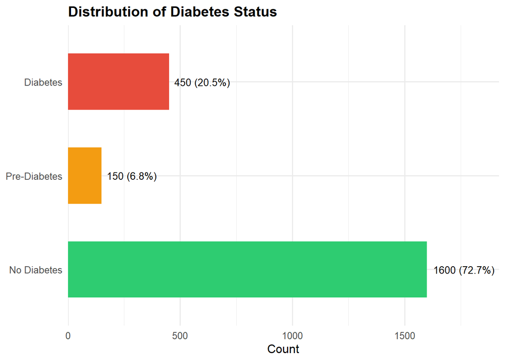

Distribution of diabetes status

```r
dat %>%
  count(diabetes_cat) %>%
  mutate(pct   = round(n / sum(n) * 100, 1),
         label = paste0(n, " (", pct, "%)")) %>%
  ggplot(aes(x = diabetes_cat, y = n, fill = diabetes_cat)) +
  geom_col(width = 0.6) +
  geom_text(aes(label = label), hjust = -0.1, size = 3.5) +
  scale_fill_manual(values = c("#2ecc71", "#f39c12", "#e74c3c")) +
  scale_y_continuous(expand = expansion(mult = c(0, 0.2))) +
  coord_flip() +
  labs(title = "Distribution of Diabetes Status", x = NULL, y = "Count") +
  theme_minimal(base_size = 12) +
  theme(legend.position = "none", plot.title = element_text(face = "bold"))
```

## 3.2 Descriptive Statistics by Outcome

```r
dat %>%
  select(diabetes_cat, HighBP, HighChol, BMI, Smoker,
         PhysActivity, GenHlth, Age, Sex, Education, Income) %>%
  tbl_summary(
    by = diabetes_cat,
    statistic = list(all_continuous()  ~ "{mean} ({sd})",
                     all_categorical() ~ "{n} ({p}%)"),
    digits = all_continuous() ~ 1,
    label = list(
      HighBP       ~ "High Blood Pressure",
      HighChol     ~ "High Cholesterol",
      BMI          ~ "BMI (continuous)",
      Smoker       ~ "Ever Smoked ≥100 cigarettes",
      PhysActivity ~ "Physical Activity (past 30 days)",
      GenHlth      ~ "General Health (self-rated)",
      Age          ~ "Age Group",
      Sex          ~ "Sex",
      Education    ~ "Education Level",
      Income       ~ "Income Category"
    )
  ) %>%
  add_overall() %>%
  bold_labels() %>%
  modify_caption("**Table 1. Descriptive Statistics by Diabetes Status**")
```

**Table 1. Descriptive Statistics by Diabetes Status**

| **Characteristic** | **Overall** N = 2,200<sup>1</sup> | **No Diabetes** N = 1,600<sup>1</sup> | **Pre-Diabetes** N = 150<sup>1</sup> | **Diabetes** N = 450<sup>1</sup> |
| --- | --- | --- | --- | --- |
| High Blood Pressure | 998 (45%) | 580 (36%) | 88 (59%) | 330 (73%) |
| High Cholesterol | 1,014 (46%) | 619 (39%) | 92 (61%) | 303 (67%) |
| BMI (continuous) | 28.7 (6.6) | 27.7 (6.1) | 29.1 (5.6) | 32.2 (7.4) |
| Ever Smoked ≥100 cigarettes | 980 (45%) | 673 (42%) | 79 (53%) | 228 (51%) |
| Physical Activity (past 30 days) | 1,627 (74%) | 1,242 (78%) | 112 (75%) | 273 (61%) |
| General Health (self-rated) |  |  |  |  |
| Excellent | 338 (15%) | 300 (19%) | 20 (13%) | 18 (4.0%) |
| Very Good | 721 (33%) | 620 (39%) | 33 (22%) | 68 (15%) |
| Good | 689 (31%) | 463 (29%) | 57 (38%) | 169 (38%) |
| Fair | 328 (15%) | 165 (10%) | 28 (19%) | 135 (30%) |
| Poor | 124 (5.6%) | 52 (3.3%) | 12 (8.0%) | 60 (13%) |
| Age Group |  |  |  |  |
| 18-34 | 202 (9.2%) | 190 (12%) | 5 (3.3%) | 7 (1.6%) |
| 35-44 | 216 (9.8%) | 193 (12%) | 6 (4.0%) | 17 (3.8%) |
| 45-54 | 400 (18%) | 323 (20%) | 25 (17%) | 52 (12%) |
| 55-64 | 569 (26%) | 403 (25%) | 38 (25%) | 128 (28%) |
| 65-74 | 514 (23%) | 312 (20%) | 41 (27%) | 161 (36%) |
| 75+ | 299 (14%) | 179 (11%) | 35 (23%) | 85 (19%) |
| Sex |  |  |  |  |
| Female | 1,210 (55%) | 906 (57%) | 79 (53%) | 225 (50%) |
| Male | 990 (45%) | 694 (43%) | 71 (47%) | 225 (50%) |
| Education Level |  |  |  |  |
| Never attended | 3 (0.1%) | 2 (0.1%) | 0 (0%) | 1 (0.2%) |
| Elementary | 38 (1.7%) | 18 (1.1%) | 4 (2.7%) | 16 (3.6%) |
| Some high school | 79 (3.6%) | 49 (3.1%) | 7 (4.7%) | 23 (5.1%) |
| High school grad | 590 (27%) | 386 (24%) | 49 (33%) | 155 (34%) |
| Some college | 610 (28%) | 440 (28%) | 42 (28%) | 128 (28%) |
| College grad | 880 (40%) | 705 (44%) | 48 (32%) | 127 (28%) |
| Income Category |  |  |  |  |
| <$10k | 97 (4.4%) | 58 (3.6%) | 8 (5.3%) | 31 (6.9%) |
| $10-15k | 116 (5.3%) | 52 (3.3%) | 9 (6.0%) | 55 (12%) |
| $15-20k | 177 (8.0%) | 100 (6.3%) | 11 (7.3%) | 66 (15%) |
| $20-25k | 180 (8.2%) | 113 (7.1%) | 17 (11%) | 50 (11%) |
| $25-35k | 243 (11%) | 175 (11%) | 27 (18%) | 41 (9.1%) |
| $35-50k | 307 (14%) | 224 (14%) | 19 (13%) | 64 (14%) |
| $50-75k | 358 (16%) | 276 (17%) | 23 (15%) | 59 (13%) |
| >$75k | 722 (33%) | 602 (38%) | 36 (24%) | 84 (19%) |

<sup>1</sup> n (%); Mean (SD)

# 4 Model Building

## 4.1 Univariable Screening

All candidate predictors are screened individually using separate proportional odds models (`clm`). Variables with **p < 0.25** (Hosmer-Lemeshow criterion) are considered for the multivariable model.

```r
dat %>%
  select(diabetes_cat,
         HighBP, HighChol, BMI, Smoker, PhysActivity, GenHlth, Age, Sex,
         Education, Income, CholCheck, Stroke, HeartDiseaseorAttack,
         Fruits, Veggies, HvyAlcoholConsump, AnyHealthcare, NoDocbcCost,
         DiffWalk) %>%
  tbl_uvregression(
    method       = clm,
    y            = diabetes_cat,
    exponentiate = TRUE,
    hide_n       = TRUE
  ) %>%
  bold_p(t = 0.25) %>%
  bold_labels() %>%
  modify_caption("**Table 2. Univariable Screening : Unadjusted Odds Ratios (bold = p < 0.25)**")
```

**Table 2. Univariable Screening : Unadjusted Odds Ratios (bold = p < 0.25)**

| **Characteristic** | **OR** | **95% CI** | **p-value** |
| --- | --- | --- | --- |
| HighBP |  |  |  |
| No | — | — |  |
| Yes | 4.12 | 3.38, 5.04 | <0.001 |
| HighChol |  |  |  |
| No | — | — |  |
| Yes | 3.05 | 2.51, 3.70 | <0.001 |
| BMI | 1.09 | 1.08, 1.11 | <0.001 |
| Smoker |  |  |  |
| No | — | — |  |
| Yes | 1.42 | 1.18, 1.72 | <0.001 |
| PhysActivity |  |  |  |
| No | — | — |  |
| Yes | 0.50 | 0.41, 0.61 | <0.001 |
| GenHlth |  |  |  |
| Excellent | — | — |  |
| Very Good | 1.32 | 0.89, 1.98 | 0.2 |
| Good | 3.97 | 2.77, 5.84 | <0.001 |
| Fair | 8.30 | 5.63, 12.5 | <0.001 |
| Poor | 11.4 | 7.14, 18.6 | <0.001 |
| Age |  |  |  |
| 18-34 | — | — |  |
| 35-44 | 1.91 | 0.94, 4.07 | 0.081 |
| 45-54 | 3.76 | 2.07, 7.43 | <0.001 |
| 55-64 | 6.64 | 3.76, 12.9 | <0.001 |
| 65-74 | 10.5 | 5.95, 20.3 | <0.001 |
| 75+ | 10.3 | 5.71, 20.1 | <0.001 |
| Sex |  |  |  |
| Female | — | — |  |
| Male | 1.27 | 1.06, 1.54 | 0.011 |
| Education |  |  |  |
| Never attended | — | — |  |
| Elementary | 1.93 | 0.17, 43.6 | 0.6 |
| Some high school | 1.08 | 0.10, 23.9 | >0.9 |
| High school grad | 0.93 | 0.09, 20.2 | >0.9 |
| Some college | 0.69 | 0.06, 14.9 | 0.8 |
| College grad | 0.44 | 0.04, 9.52 | 0.5 |
| Income |  |  |  |
| <$10k | — | — |  |
| $10-15k | 1.89 | 1.11, 3.23 | 0.019 |
| $15-20k | 1.19 | 0.73, 1.96 | 0.5 |
| $20-25k | 0.86 | 0.53, 1.42 | 0.6 |
| $25-35k | 0.54 | 0.33, 0.88 | 0.013 |
| $35-50k | 0.55 | 0.34, 0.88 | 0.013 |
| $50-75k | 0.43 | 0.27, 0.70 | <0.001 |
| >$75k | 0.29 | 0.19, 0.46 | <0.001 |
| CholCheck |  |  |  |
| No | — | — |  |
| Yes | 6.29 | 2.59, 20.7 | <0.001 |
| Stroke |  |  |  |
| No | — | — |  |
| Yes | 3.44 | 2.31, 5.13 | <0.001 |
| HeartDiseaseorAttack |  |  |  |
| No | — | — |  |
| Yes | 3.61 | 2.76, 4.73 | <0.001 |
| Fruits |  |  |  |
| No | — | — |  |
| Yes | 0.66 | 0.55, 0.80 | <0.001 |
| Veggies |  |  |  |
| No | — | — |  |
| Yes | 0.72 | 0.57, 0.90 | 0.004 |
| HvyAlcoholConsump |  |  |  |
| No | — | — |  |
| Yes | 0.49 | 0.29, 0.79 | 0.005 |
| AnyHealthcare |  |  |  |
| No | — | — |  |
| Yes | 1.30 | 0.83, 2.13 | 0.3 |
| NoDocbcCost |  |  |  |
| No | — | — |  |
| Yes | 0.95 | 0.68, 1.31 | 0.8 |
| DiffWalk |  |  |  |
| No | — | — |  |
| Yes | 3.45 | 2.78, 4.30 | <0.001 |

Abbreviations: CI = Confidence Interval, OR = Odds Ratio

**Screening decision:** Bold p-values mark variables meeting the p < 0.25 entry criterion. From those, the multivariable model retains predictors selected on clinical relevance and established BRFSS literature: **High Blood Pressure, High Cholesterol, BMI, Smoking, Physical Activity, General Health, Sex, and Age group.** Variables passing the screen but not retained (e.g., Fruits, Veggies, HvyAlcoholConsump) did not meet the clinical relevance threshold for the primary model.

## 4.2 Full Adjusted Model

The proportional odds model is fitted using `ordinal::clm()` with the logit link. Two sets of parameters are estimated simultaneously:

- **Threshold parameters** (α₁, α₂) : the two log-odds boundaries separating the three ordered categories (*No Diabetes|Pre-Diabetes* and *Pre-Diabetes|Diabetes*). These are nuisance parameters that define the model’s internal cut-points and carry no direct clinical meaning.
- **Regression coefficients** (β) : one per predictor, shared across both thresholds under the proportional odds constraint. Positive β indicates association with more severe diabetes, and negative β is protective.

The `summary()` output has two blocks: (1) **Threshold coefficients** (the α cut-points) and (2) **Coefficients** (the β estimates with SE, z-statistic, and p-value). Clinical inference comes from the Coefficients block only.

```r
m_full <- clm(diabetes_cat ~ HighBP + HighChol + BMI + Smoker +
                PhysActivity + GenHlth + Sex + Age,
              data = dat,
              link = "logit")

summary(m_full)
```

```
formula:
diabetes_cat ~ HighBP + HighChol + BMI + Smoker + PhysActivity + GenHlth + Sex + Age
data:    dat

 link  threshold nobs logLik   AIC     niter max.grad cond.H
 logit flexible  2200 -1336.95 2707.91 7(1)  5.26e-12 2.6e+05

Coefficients:
                  Estimate Std. Error z value Pr(>|z|)
HighBPYes         0.554924   0.118217   4.694 2.68e-06 ***
HighCholYes       0.498718   0.114032   4.373 1.22e-05 ***
BMI               0.074296   0.008689   8.550  < 2e-16 ***
SmokerYes        -0.027268   0.109675  -0.249   0.8036
PhysActivityYes  -0.152784   0.121271  -1.260   0.2077
GenHlthVery Good  0.006088   0.212301   0.029   0.9771
GenHlthGood       0.807110   0.203834   3.960 7.51e-05 ***
GenHlthFair       1.396029   0.221707   6.297 3.04e-10 ***
GenHlthPoor       1.728486   0.274202   6.304 2.91e-10 ***
SexMale           0.214885   0.108337   1.983   0.0473 *
Age35-44          0.331358   0.391263   0.847   0.3971
Age45-54          0.745298   0.342239   2.178   0.0294 *
Age55-64          1.290130   0.331552   3.891 9.98e-05 ***
Age65-74          1.814694   0.332316   5.461 4.74e-08 ***
Age75+            1.771905   0.341825   5.184 2.18e-07 ***
---
Signif. codes:  0 '***' 0.001 '**' 0.01 '*' 0.05 '.' 0.1 ' ' 1

Threshold coefficients:
                         Estimate Std. Error z value
No Diabetes|Pre-Diabetes   5.6275     0.4553   12.36
Pre-Diabetes|Diabetes      6.1171     0.4586   13.34
```

# 5 Model Diagnostics

## 5.1 Multicollinearity Check

`ordinal::clm()` does not have a native VIF method. A proxy linear model fitted to the same predictors provides a well-accepted VIF approximation via `car::vif()`.

```r
mod_lm_vif <- lm(as.numeric(diabetes_cat) ~ HighBP + HighChol + BMI + Smoker +
                   PhysActivity + GenHlth + Sex + Age,
                 data = dat)

vif_mat     <- car::vif(mod_lm_vif)
vif_adj     <- vif_mat[, 3]
vif_max     <- round(max(vif_adj), 2)
vif_top     <- names(which.max(vif_adj))
vif_concern <- vif_adj[vif_adj >= 2.0]
vif_mat
```

```
                 GVIF Df GVIF^(1/(2*Df))
HighBP       1.331725  1        1.154004
HighChol     1.197119  1        1.094129
BMI          1.145243  1        1.070160
Smoker       1.072630  1        1.035678
PhysActivity 1.108305  1        1.052761
GenHlth      1.287816  4        1.032124
Sex          1.031206  1        1.015483
Age          1.265208  5        1.023803
```

**Interpretation:** All GVIF^(1/(2·Df)) values fall below 2.0. The highest adjusted VIF is 1.15 for HighBP. No predictor shows problematic collinearity, thus coefficients and standard errors are interpreted without reservation.

## 5.2 BMI Linearity Check

The proportional odds model assumes a log-linear relationship between BMI and diabetes severity on the log-odds scale. This is checked by computing the Pearson correlation between BMI quartile midpoints and empirical log-odds at both cumulative thresholds.

```r
bmi_lo <- dat %>%
  mutate(BMI_q = cut(BMI,
                     breaks = quantile(BMI, probs = seq(0, 1, 0.25), na.rm = TRUE),
                     include.lowest = TRUE)) %>%
  group_by(BMI_q) %>%
  summarise(
    BMI_mid = mean(BMI),
    lo_pre  = qlogis(pmin(pmax(mean(as.integer(diabetes_cat) >= 2), 1e-6), 1 - 1e-6)),
    lo_dia  = qlogis(pmin(pmax(mean(as.integer(diabetes_cat) >= 3), 1e-6), 1 - 1e-6)),
    .groups = "drop"
  )

bmi_cor_pre <- round(cor(bmi_lo$BMI_mid, bmi_lo$lo_pre), 3)
bmi_cor_dia <- round(cor(bmi_lo$BMI_mid, bmi_lo$lo_dia), 3)

tibble(Threshold   = c("≥ Pre-Diabetes", "≥ Diabetes"),
       Correlation = c(bmi_cor_pre, bmi_cor_dia)) %>%
  kable(caption = "Pearson correlation : BMI quartile midpoint vs empirical log-odds",
        digits = 3) %>%
  kable_styling(bootstrap_options = "striped", full_width = FALSE)
```

Pearson correlation : BMI quartile midpoint vs empirical log-odds

| Threshold | Correlation |
| --- | --- |
| ≥ Pre-Diabetes | 0.950 |
| ≥ Diabetes | 0.951 |

Empirical log-odds of P(Y ≥ j) across BMI quartiles.

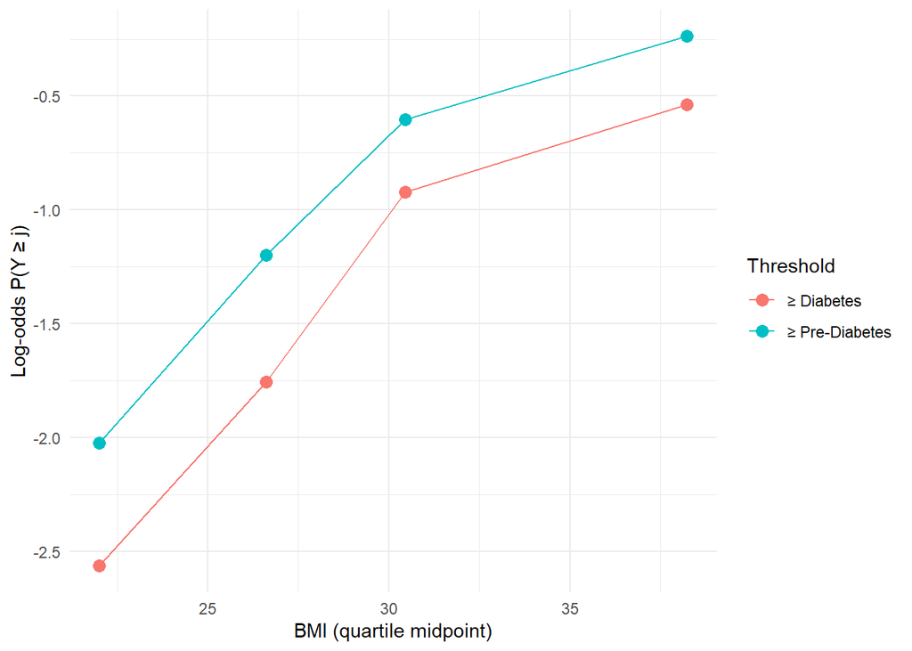

Empirical log-odds of P(Y ≥ j) across BMI quartiles.

```r
bmi_lo %>%
  pivot_longer(c(lo_pre, lo_dia), names_to = "threshold", values_to = "log_odds") %>%
  mutate(threshold = dplyr::case_match(threshold,
    "lo_pre" ~ "≥ Pre-Diabetes",
    "lo_dia" ~ "≥ Diabetes")) %>%
  ggplot(aes(x = BMI_mid, y = log_odds, colour = threshold)) +
  geom_point(size = 3) + geom_line() +
  labs(x = "BMI (quartile midpoint)", y = "Log-odds P(Y ≥ j)", colour = "Threshold") +
  theme_minimal()
```

# 6 Model Results

## 6.1 Adjusted Odds Ratios

Results are presented as exponentiated coefficients (odds ratios). OR > 1 indicates association with higher odds of more severe diabetes, and OR < 1 is protective. All ORs are adjusted for all other predictors in the model.

```r
or_tbl <- tidy(m_full, exponentiate = TRUE, conf.int = TRUE) %>%
  filter(coef.type == "location")

n_terms  <- nrow(or_tbl)
n_sig    <- sum(or_tbl$p.value < 0.05, na.rm = TRUE)
nonsig_t <- term_label(or_tbl$term[or_tbl$p.value >= 0.05])

cat(sprintf("Total predictor terms : %d\n", n_terms))
```

```
Total predictor terms : 15
```

```r
cat(sprintf("Significant (α = 0.05): %d\n", n_sig))
```

```
Significant (α = 0.05): 11
```

```r
if (length(nonsig_t) > 0)
  cat(sprintf("Non-significant       : %s\n", paste(nonsig_t, collapse = ", ")))
```

```
Non-significant       : Ever Smoked (Yes vs No), Physical Activity past 30 days (Yes vs No), General Health: Very Good vs Excellent, Age: 35–44 vs 18–34
```

```r
or_tbl %>%
  mutate(term = term_label(term)) %>%
  select(term, estimate, conf.low, conf.high, p.value) %>%
  kable(digits = 3,
        col.names = c("Predictor", "OR", "95% CI Lower", "95% CI Upper", "p-value"),
        caption = "Table 3. Adjusted Odds Ratios : Ordinal Logistic Regression") %>%
  kable_styling(bootstrap_options = c("striped", "hover")) %>%
  row_spec(0, bold = TRUE) %>%
  footnote(general = "Reference: HighBP = No, HighChol = No, Smoker = No, PhysActivity = No, GenHlth = Excellent, Sex = Female, Age = 18–34.")
```

Table 3. Adjusted Odds Ratios : Ordinal Logistic Regression

| Predictor | OR | 95% CI Lower | 95% CI Upper | p-value |
| --- | --- | --- | --- | --- |
| High Blood Pressure (Yes vs No) | 1.742 | 1.382 | 2.197 | 0.000 |
| High Cholesterol (Yes vs No) | 1.647 | 1.317 | 2.060 | 0.000 |
| BMI (per 1-unit increase) | 1.077 | 1.059 | 1.096 | 0.000 |
| Ever Smoked (Yes vs No) | 0.973 | 0.785 | 1.206 | 0.804 |
| Physical Activity past 30 days (Yes vs No) | 0.858 | 0.678 | 1.090 | 0.208 |
| General Health: Very Good vs Excellent | 1.006 | 0.668 | 1.539 | 0.977 |
| General Health: Good vs Excellent | 2.241 | 1.517 | 3.378 | 0.000 |
| General Health: Fair vs Excellent | 4.039 | 2.635 | 6.294 | 0.000 |
| General Health: Poor vs Excellent | 5.632 | 3.308 | 9.706 | 0.000 |
| Sex: Male vs Female | 1.240 | 1.003 | 1.533 | 0.047 |
| Age: 35–44 vs 18–34 | 1.393 | 0.657 | 3.081 | 0.397 |
| Age: 45–54 vs 18–34 | 2.107 | 1.113 | 4.301 | 0.029 |
| Age: 55–64 vs 18–34 | 3.633 | 1.967 | 7.289 | 0.000 |
| Age: 65–74 vs 18–34 | 6.139 | 3.320 | 12.336 | 0.000 |
| Age: 75+ vs 18–34 | 5.882 | 3.115 | 12.013 | 0.000 |

Note:  
Reference: HighBP = No, HighChol = No, Smoker = No, PhysActivity = No, GenHlth = Excellent, Sex = Female, Age = 18–34.

## 6.2 Threshold Coefficients

```r
thresh_df <- tidy(m_full, conf.int = TRUE) %>% filter(coef.type == "intercept")
t1_val    <- round(thresh_df$estimate[thresh_df$term == "No Diabetes|Pre-Diabetes"], 3)
t2_val    <- round(thresh_df$estimate[thresh_df$term == "Pre-Diabetes|Diabetes"], 3)

cat(sprintf("Threshold 1 (No Diabetes | Pre-Diabetes) = %.3f\n", t1_val))
```

```
Threshold 1 (No Diabetes | Pre-Diabetes) = 5.628
```

```r
cat(sprintf("Threshold 2 (Pre-Diabetes | Diabetes)    = %.3f\n", t2_val))
```

```
Threshold 2 (Pre-Diabetes | Diabetes)    = 6.117
```

```r
thresh_df %>%
  select(term, estimate, std.error, statistic, p.value) %>%
  kable(digits = 3,
        col.names = c("Threshold", "Estimate", "SE", "z", "p-value"),
        caption = "Table 4. Threshold Coefficients (Cut Points)") %>%
  kable_styling(bootstrap_options = c("striped", "hover", "condensed"), full_width = FALSE)
```

Table 4. Threshold Coefficients (Cut Points)

| Threshold | Estimate | SE | z | p-value |
| --- | --- | --- | --- | --- |
| No Diabetes&#124;Pre-Diabetes | 5.628 | 0.455 | 12.360 | 0 |
| Pre-Diabetes&#124;Diabetes | 6.117 | 0.459 | 13.339 | 0 |

**Interpretation:** The first threshold (`No Diabetes|Pre-Diabetes` = 5.628) is the log-odds boundary where cumulative probability shifts from *No Diabetes* into the higher categories. The second (`Pre-Diabetes|Diabetes` = 6.117) marks the boundary into *Diabetes* alone. Since 6.117 > 5.628, the thresholds are correctly ordered, thus no reversal, confirming internal model consistency. Both are nuisance parameters and not interpreted clinically.

# 7 Proportional Odds Assumption

The **proportional odds assumption** (parallel regression assumption) requires that the OR for each predictor is constant across both cumulative thresholds. Two formal tests are applied using the `ordinal` package.

> **Note on Brant test:** The Brant test (via `MASS::polr()`) is not applied here. With only n = 150 in the Pre-Diabetes category and multi-level predictors (GenHlth: 4 levels, Age: 6 levels), the test consistently fails to converge, thus fitting separate binary logistic models at each threshold becomes computationally infeasible with sparse middle-category cells. `nominal_test()` and `scale_test()` from `ordinal` are the more appropriate assessments for `clm()` models.

## 7.1 Nominal Test

The nominal test compares the fitted model against one where each predictor is allowed a different effect at each threshold. A significant p-value (p < 0.05) means the effect of that predictor varies across thresholds, which is a violation of proportional odds.

```r
nt_res    <- nominal_test(m_full)
nt_pvals  <- nt_res[["Pr(>Chi)"]]
names(nt_pvals) <- rownames(nt_res)
nt_pvals  <- nt_pvals[names(nt_pvals) != "<none>"]   # exclude baseline row
nt_fail   <- names(nt_pvals[!is.na(nt_pvals) & nt_pvals < 0.05])
nt_pass   <- names(nt_pvals[!is.na(nt_pvals) & nt_pvals >= 0.05])
nt_na     <- names(nt_pvals[is.na(nt_pvals)])

cat(sprintf("Violate assumption (p < 0.05): %s\n",
            if(length(nt_fail) > 0) paste(nt_fail, collapse = ", ") else "none"))
```

```
Violate assumption (p < 0.05): BMI
```

```r
cat(sprintf("Hold assumption   (p ≥ 0.05): %s\n",
            if(length(nt_pass) > 0) paste(nt_pass, collapse = ", ") else "none"))
```

```
Hold assumption   (p ≥ 0.05): HighBP, HighChol, Smoker, PhysActivity, GenHlth, Sex, Age
```

```r
cat(sprintf("Returned NA                 : %s\n",
            if(length(nt_na) > 0) paste(nt_na, collapse = ", ") else "none"))
```

```
Returned NA                 : none
```

```r
nt_res
```

```
Tests of nominal effects

formula: diabetes_cat ~ HighBP + HighChol + BMI + Smoker + PhysActivity + GenHlth + Sex + Age
             Df  logLik    AIC    LRT Pr(>Chi)
<none>          -1337.0 2707.9
HighBP        1 -1336.2 2708.5 1.4064 0.235648
HighChol      1 -1336.9 2709.8 0.1112 0.738745
BMI           1 -1333.2 2702.3 7.5763 0.005914 **
Smoker        1 -1336.4 2708.9 1.0529 0.304847
PhysActivity  1 -1335.1 2706.2 3.6956 0.054557 .
GenHlth       4 -1333.5 2709.1 6.8583 0.143571
Sex           1 -1336.9 2709.9 0.0449 0.832239
Age           5 -1335.1 2714.2 3.7314 0.588691
---
Signif. codes:  0 '***' 0.001 '**' 0.01 '*' 0.05 '.' 0.1 ' ' 1
```

**Interpretation:** 1 of 8 predictors showed significant deviation from proportional odds (p < 0.05): BMI. 7 predictor(s) held the assumption: HighBP, HighChol, Smoker, PhysActivity, GenHlth, Sex, Age. Flagged predictors have effects that differ in magnitude across the two thresholds (not necessarily in direction). With n = 2200, this test is sensitive enough to pick up trivially small deviations, and statistical significance alone does not determine whether the violation is practically meaningful.

## 7.2 Scale Test

The scale test checks whether the variance of the underlying latent variable differs across predictor levels, indicating heteroscedasticity on the latent scale. A significant result means the spread of the latent diabetes severity distribution is not constant across that predictor’s levels.

```r
st_res    <- scale_test(m_full)
st_pvals  <- st_res[["Pr(>Chi)"]]
names(st_pvals) <- rownames(st_res)
st_pvals  <- st_pvals[names(st_pvals) != "<none>"]   # exclude baseline row
st_fail   <- names(st_pvals[!is.na(st_pvals) & st_pvals < 0.05])
st_pass   <- names(st_pvals[!is.na(st_pvals) & st_pvals >= 0.05])

cat(sprintf("Significant scale effect (p < 0.05): %s\n",
            if(length(st_fail) > 0) paste(st_fail, collapse = ", ") else "none"))
```

```
Significant scale effect (p < 0.05): BMI, Smoker, PhysActivity, GenHlth
```

```r
cat(sprintf("No scale effect          (p ≥ 0.05): %s\n",
            if(length(st_pass) > 0) paste(st_pass, collapse = ", ") else "none"))
```

```
No scale effect          (p ≥ 0.05): HighBP, HighChol, Sex, Age
```

```r
st_res
```

```
Tests of scale effects

formula: diabetes_cat ~ HighBP + HighChol + BMI + Smoker + PhysActivity + GenHlth + Sex + Age
             Df  logLik    AIC     LRT  Pr(>Chi)
<none>          -1337.0 2707.9
HighBP        1 -1336.1 2708.2  1.7540  0.185370
HighChol      1 -1336.9 2709.8  0.0781  0.779956
BMI           1 -1327.5 2691.1 18.8163 1.439e-05 ***
Smoker        1 -1334.8 2705.6  4.3006  0.038098 *
PhysActivity  1 -1332.0 2700.0  9.8946  0.001658 **
GenHlth       4 -1331.6 2705.1 10.7915  0.029010 *
Sex           1 -1336.9 2709.8  0.0976  0.754718
Age           5 -1336.0 2716.1  1.8332  0.871713
---
Signif. codes:  0 '***' 0.001 '**' 0.01 '*' 0.05 '.' 0.1 ' ' 1
```

**Interpretation:** 4 predictor(s) showed a significant scale effect (p < 0.05): BMI, Smoker, PhysActivity, GenHlth. 4 predictor(s) showed no scale effect: HighBP, HighChol, Sex, Age. Latent variance is not constant across levels of the flagged predictors, and OR estimates for those predictors carry this caveat.

# 8 Model Fit

## 8.1 Global Likelihood Ratio Test

```r
m_null     <- clm(diabetes_cat ~ 1, data = dat)
lrt_global <- anova(m_null, m_full)
lrt_chi    <- round(lrt_global[2, "LR.stat"], 1)
lrt_df     <- lrt_global[2, "df"]

cat(sprintf("Global LRT: χ²(%d) = %.1f, p < 0.001\n", lrt_df, lrt_chi))
```

```
Global LRT: χ²(15) = 579.1, p < 0.001
```

```r
cat(sprintf("AIC — Null: %.0f  |  Full: %.0f  |  ΔAIC: %.0f\n",
            AIC(m_null), AIC(m_full), AIC(m_null) - AIC(m_full)))
```

```
AIC — Null: 3257  |  Full: 2708  |  ΔAIC: 549
```

```r
lrt_global
```

```
Likelihood ratio tests of cumulative link models:

       formula:
m_null diabetes_cat ~ 1
m_full diabetes_cat ~ HighBP + HighChol + BMI + Smoker + PhysActivity + GenHlth + Sex + Age
       link: threshold:
m_null logit flexible
m_full logit flexible

       no.par    AIC  logLik LR.stat df Pr(>Chisq)
m_null      2 3257.0 -1626.5
m_full     17 2707.9 -1337.0  579.09 15  < 2.2e-16 ***
---
Signif. codes:  0 '***' 0.001 '**' 0.01 '*' 0.05 '.' 0.1 ' ' 1
```

**Interpretation:** The full model significantly improves fit over the null (LRT χ²(15) = 579.1, p < 0.001). AIC dropped from 3257 to 2708, a reduction of 549 points. The 8 predictors collectively explain substantial variation in diabetes severity beyond what the intercepts alone capture.

## 8.2 Pseudo R²

```r
loglik_full <- as.numeric(logLik(m_full))
loglik_null <- as.numeric(logLik(m_null))
n           <- nrow(dat)

r2_mcf <- 1 - (loglik_full / loglik_null)
r2_cox <- 1 - exp((2 / n) * (loglik_null - loglik_full))
r2_nag <- r2_cox / (1 - exp((2 / n) * loglik_null))

cat(sprintf("McFadden Pseudo R²   = %.4f\n", r2_mcf))
```

```
McFadden Pseudo R²   = 0.1780
```

```r
cat(sprintf("Nagelkerke Pseudo R² = %.4f\n", r2_nag))
```

```
Nagelkerke Pseudo R² = 0.2998
```

**Interpretation:** McFadden R² = 0.178 and Nagelkerke R² = 0.3. McFadden R² of 0.178 is below 0.20. The current 8 predictors explain a limited proportion of variation in diabetes severity. Nagelkerke R² = 0.3 is the preferred metric in health sciences reporting.

## 8.3 Variable Contribution (Drop-one LRT)

```r
d1_res    <- drop1(m_full, test = "Chi")
d1_pred   <- d1_res[rownames(d1_res) != "<none>", ]
d1_pcol   <- names(d1_pred)[ncol(d1_pred)]
top3      <- paste(term_label(rownames(d1_pred)[order(d1_pred$LRT, decreasing = TRUE)[1:3]]),
                   collapse = ", ")
d1_nonsig <- rownames(d1_pred)[!is.na(d1_pred[[d1_pcol]]) & d1_pred[[d1_pcol]] > 0.05]
n_nonsig  <- length(d1_nonsig)

cat(sprintf("Top 3 contributors: %s\n", top3))
```

```
Top 3 contributors: GenHlth, Age, BMI (per 1-unit increase)
```

```r
cat(sprintf("Non-significant predictors (p > 0.05): %s\n",
            if(n_nonsig > 0) paste(term_label(d1_nonsig), collapse = ", ") else "none"))
```

```
Non-significant predictors (p > 0.05): Smoker, PhysActivity
```

```r
d1_res
```

```
Single term deletions

Model:
diabetes_cat ~ HighBP + HighChol + BMI + Smoker + PhysActivity +
    GenHlth + Sex + Age
             Df    AIC     LRT  Pr(>Chi)
<none>          2707.9
HighBP        1 2728.0  22.133 2.543e-06 ***
HighChol      1 2725.1  19.230 1.159e-05 ***
BMI           1 2784.1  78.205 < 2.2e-16 ***
Smoker        1 2706.0   0.062   0.80361
PhysActivity  1 2707.5   1.576   0.20938
GenHlth       4 2809.0 109.055 < 2.2e-16 ***
Sex           1 2709.8   3.934   0.04731 *
Age           5 2787.6  89.657 < 2.2e-16 ***
---
Signif. codes:  0 '***' 0.001 '**' 0.01 '*' 0.05 '.' 0.1 ' ' 1
```

**Interpretation:** The three largest independent contributions come from **GenHlth, Age, BMI (per 1-unit increase)**. 2 predictor(s) did not reach significance in the drop-one test (p > 0.05): Smoker, PhysActivity. Their independent contribution beyond the remaining predictors is marginal in this sample.

# 9 Interaction Analysis

One a priori biologically plausible interaction is tested: **`HighBP × BMI`**. Hypertension and obesity share the insulin-resistance pathway, so the per-unit BMI association with diabetes severity may differ between those with and without high blood pressure.

```r
m_int   <- clm(diabetes_cat ~ HighBP * BMI + HighChol + Smoker +
                 PhysActivity + GenHlth + Sex + Age,
               data = dat, link = "logit")

int_lrt <- anova(m_full, m_int)
int_chi <- round(int_lrt[2, "LR.stat"], 2)
int_df  <- int_lrt[2, "df"]
int_p   <- int_lrt[2, "Pr(>Chisq)"]

cat(sprintf("LRT (HighBP × BMI interaction): χ²(%d) = %.2f, p = %.3f\n",
            int_df, int_chi, int_p))
```

```
LRT (HighBP × BMI interaction): χ²(1) = 0.08, p = 0.783
```

```r
int_lrt
```

```
Likelihood ratio tests of cumulative link models:

       formula:
m_full diabetes_cat ~ HighBP + HighChol + BMI + Smoker + PhysActivity + GenHlth + Sex + Age
m_int  diabetes_cat ~ HighBP * BMI + HighChol + Smoker + PhysActivity + GenHlth + Sex + Age
       link: threshold:
m_full logit flexible
m_int  logit flexible

       no.par    AIC  logLik LR.stat df Pr(>Chisq)
m_full     17 2707.9 -1337.0
m_int      18 2709.8 -1336.9  0.0761  1     0.7827
```

```r
int_or_tbl <- tidy(m_int, exponentiate = TRUE, conf.int = TRUE) %>%
  filter(coef.type == "location", str_detect(term, ":"))

int_or_val <- round(int_or_tbl$estimate[1], 3)
int_ci_lo  <- round(int_or_tbl$conf.low[1], 3)
int_ci_hi  <- round(int_or_tbl$conf.high[1], 3)
int_or_p   <- int_or_tbl$p.value[1]

cat(sprintf("HighBP × BMI interaction OR = %.3f (95%% CI: %.3f–%.3f, p = %.3f)\n",
            int_or_val, int_ci_lo, int_ci_hi, int_or_p))
```

```
HighBP × BMI interaction OR = 0.995 (95% CI: 0.963–1.029, p = 0.783)
```

```r
int_or_tbl %>%
  select(term, estimate, conf.low, conf.high, p.value) %>%
  kable(caption = "Interaction term — OR and 95% CI", digits = 3,
        col.names = c("Term", "OR", "95% CI Lower", "95% CI Upper", "p-value")) %>%
  kable_styling(bootstrap_options = c("striped", "hover"))
```

Interaction term — OR and 95% CI

| Term | OR | 95% CI Lower | 95% CI Upper | p-value |
| --- | --- | --- | --- | --- |
| HighBPYes:BMI | 0.995 | 0.963 | 1.029 | 0.783 |

**Interpretation:** Adding the `HighBP × BMI` interaction does not significantly improve model fit (χ²(1) = 0.08, p = 0.783). The main-effects model is retained on parsimony grounds, as the per-unit BMI association does not meaningfully differ by hypertension status in this sample.

# 10 Model Comparison

```r
m_reduced <- clm(diabetes_cat ~ HighBP + HighChol + BMI + GenHlth + Sex + Age,
                 data = dat, link = "logit")

tibble(
  Model  = c("Null (intercept only)",
             "Reduced (−Smoker, −PhysActivity)",
             "Full model"),
  logLik = c(as.numeric(logLik(m_null)),
             as.numeric(logLik(m_reduced)),
             as.numeric(logLik(m_full))),
  df     = c(attr(logLik(m_null),    "df"),
             attr(logLik(m_reduced), "df"),
             attr(logLik(m_full),    "df")),
  AIC    = c(AIC(m_null), AIC(m_reduced), AIC(m_full)),
  BIC    = c(BIC(m_null), BIC(m_reduced), BIC(m_full))
) %>%
  arrange(AIC) %>%
  kable(digits = 1, caption = "Table 5. Model Comparison — log-likelihood, df, AIC, and BIC") %>%
  kable_styling(bootstrap_options = c("striped", "hover"))
```

Table 5. Model Comparison — log-likelihood, df, AIC, and BIC

| Model | logLik | df | AIC | BIC |
| --- | --- | --- | --- | --- |
| Reduced (−Smoker, −PhysActivity) | -1337.8 | 15 | 2705.5 | 2791.0 |
| Full model | -1337.0 | 17 | 2707.9 | 2804.7 |
| Null (intercept only) | -1626.5 | 2 | 3257.0 | 3268.4 |

```r
lrt_red      <- anova(m_reduced, m_full)
lrt_red_p    <- lrt_red[2, "Pr(>Chisq)"]
lrt_red_pfmt <- ifelse(lrt_red_p < 0.001, "< 0.001", sprintf("= %.3f", lrt_red_p))
full_best    <- AIC(m_full) < AIC(m_reduced)
delta_aic    <- round(AIC(m_reduced) - AIC(m_full), 1)
delta_bic    <- round(BIC(m_reduced) - BIC(m_full), 1)

cat(sprintf("LRT p-value (Smoker + PhysActivity jointly): p %s\n", lrt_red_pfmt))
```

```
LRT p-value (Smoker + PhysActivity jointly): p = 0.449
```

```r
lrt_red
```

```
Likelihood ratio tests of cumulative link models:

          formula:
m_reduced diabetes_cat ~ HighBP + HighChol + BMI + GenHlth + Sex + Age
m_full    diabetes_cat ~ HighBP + HighChol + BMI + Smoker + PhysActivity + GenHlth + Sex + Age
          link: threshold:
m_reduced logit flexible
m_full    logit flexible

          no.par    AIC  logLik LR.stat df Pr(>Chisq)
m_reduced     15 2705.5 -1337.8
m_full        17 2707.9 -1337.0   1.602  2     0.4489
```

**Interpretation:** The reduced model (AIC = 2705.5, BIC = 2791) outperforms the full model (AIC = 2707.9, BIC = 2804.7, ΔAIC = 2.4 favouring reduced). Adding Smoker and PhysActivity does not recover the 2-parameter AIC penalty. The LRT shows Smoker and PhysActivity do **not** jointly improve fit beyond the remaining predictors (p = 0.449). The reduced model is statistically preferred. Both are retained here on clinical grounds and their marginal statistical contribution in this sample should be noted as a limitation.

# 11 Interpretation of Results

## 11.1 Proportional Odds Interpretation Framework

In the proportional odds model, the **OR for each predictor is constant across both cut points**:

- The odds of *Pre-Diabetes or Diabetes* vs. *No Diabetes*, **and**
- The odds of *Diabetes* vs. *No Diabetes or Pre-Diabetes*

OR > 1 means greater probability of a more severe category (not a specific threshold).

## 11.2 Summary Table

```r
or_results <- tidy(m_full, exponentiate = TRUE, conf.int = TRUE) %>%
  filter(coef.type == "location")

or_results %>%
  mutate(term      = term_label(term),
         sig       = ifelse(p.value < 0.05, "Yes", "No"),
         direction = ifelse(estimate > 1, "Higher risk", "Lower risk")) %>%
  select(term, estimate, conf.low, conf.high, p.value, sig, direction) %>%
  kable(digits = 3,
        col.names = c("Predictor", "OR", "CI Lower", "CI Upper", "p-value",
                      "Significant?", "Direction"),
        caption = "Table 6. Adjusted Odds Ratios — Direction and Significance") %>%
  kable_styling(bootstrap_options = c("striped", "hover"))
```

Table 6. Adjusted Odds Ratios — Direction and Significance

| Predictor | OR | CI Lower | CI Upper | p-value | Significant? | Direction |
| --- | --- | --- | --- | --- | --- | --- |
| High Blood Pressure (Yes vs No) | 1.742 | 1.382 | 2.197 | 0.000 | Yes | Higher risk |
| High Cholesterol (Yes vs No) | 1.647 | 1.317 | 2.060 | 0.000 | Yes | Higher risk |
| BMI (per 1-unit increase) | 1.077 | 1.059 | 1.096 | 0.000 | Yes | Higher risk |
| Ever Smoked (Yes vs No) | 0.973 | 0.785 | 1.206 | 0.804 | No | Lower risk |
| Physical Activity past 30 days (Yes vs No) | 0.858 | 0.678 | 1.090 | 0.208 | No | Lower risk |
| General Health: Very Good vs Excellent | 1.006 | 0.668 | 1.539 | 0.977 | No | Higher risk |
| General Health: Good vs Excellent | 2.241 | 1.517 | 3.378 | 0.000 | Yes | Higher risk |
| General Health: Fair vs Excellent | 4.039 | 2.635 | 6.294 | 0.000 | Yes | Higher risk |
| General Health: Poor vs Excellent | 5.632 | 3.308 | 9.706 | 0.000 | Yes | Higher risk |
| Sex: Male vs Female | 1.240 | 1.003 | 1.533 | 0.047 | Yes | Higher risk |
| Age: 35–44 vs 18–34 | 1.393 | 0.657 | 3.081 | 0.397 | No | Higher risk |
| Age: 45–54 vs 18–34 | 2.107 | 1.113 | 4.301 | 0.029 | Yes | Higher risk |
| Age: 55–64 vs 18–34 | 3.633 | 1.967 | 7.289 | 0.000 | Yes | Higher risk |
| Age: 65–74 vs 18–34 | 6.139 | 3.320 | 12.336 | 0.000 | Yes | Higher risk |
| Age: 75+ vs 18–34 | 5.882 | 3.115 | 12.013 | 0.000 | Yes | Higher risk |

# 12 Prediction

## 12.1 Classification Accuracy

```r
pred_class <- predict(m_full, type = "class")$fit
conf_mat   <- table(Predicted = pred_class, Observed = dat$diabetes_cat)
accuracy   <- mean(pred_class == as.character(dat$diabetes_cat))
acc_pct    <- round(accuracy * 100, 1)
per_class  <- round(diag(conf_mat) / colSums(conf_mat) * 100, 1)

cat(sprintf("Overall accuracy        = %.1f%%\n", acc_pct))
```

```
Overall accuracy        = 75.9%
```

```r
cat(sprintf("Sensitivity — No Diabetes   : %.1f%%\n", per_class["No Diabetes"]))
```

```
Sensitivity — No Diabetes   : 93.4%
```

```r
cat(sprintf("Sensitivity — Pre-Diabetes  : %.1f%%\n", per_class["Pre-Diabetes"]))
```

```
Sensitivity — Pre-Diabetes  : 0.0%
```

```r
cat(sprintf("Sensitivity — Diabetes      : %.1f%%\n", per_class["Diabetes"]))
```

```
Sensitivity — Diabetes      : 38.9%
```

```r
conf_mat %>%
  as.data.frame() %>%
  pivot_wider(names_from = Observed, values_from = Freq) %>%
  kable(caption = "Table 7. Confusion Matrix — Predicted vs Observed Diabetes Status") %>%
  kable_styling(bootstrap_options = c("striped", "hover"), full_width = FALSE)
```

Table 7. Confusion Matrix — Predicted vs Observed Diabetes Status

| Predicted | No Diabetes | Pre-Diabetes | Diabetes |
| --- | --- | --- | --- |
| No Diabetes | 1494 | 129 | 275 |
| Pre-Diabetes | 0 | 0 | 0 |
| Diabetes | 106 | 21 | 175 |

**Interpretation:** The model correctly classified 75.9% of observations overall. Per-class sensitivity: No Diabetes = 93.4%, Pre-Diabetes = 0%, Diabetes = 38.9%. Pre-Diabetes sensitivity is very low (0%), which is expected given only n = 150 cases flanked by two much larger categories. Most Pre-Diabetes misclassifications fall into adjacent categories.

## 12.2 Fitted Probabilities for Illustrative Profiles

```r
new_profiles <- data.frame(
  HighBP       = factor(c("No",  "Yes", "No",  "Yes"), levels = c("No","Yes")),
  HighChol     = factor(c("No",  "Yes", "No",  "Yes"), levels = c("No","Yes")),
  BMI          = c(22,   32,   22,   32),
  Smoker       = factor(c("No",  "No",  "Yes", "Yes"), levels = c("No","Yes")),
  PhysActivity = factor(c("Yes", "Yes", "No",  "No"),  levels = c("No","Yes")),
  GenHlth      = factor(c("Excellent","Good","Fair","Poor"),
                        levels = c("Excellent","Very Good","Good","Fair","Poor")),
  Sex          = factor(c("Female","Male","Female","Male"), levels = c("Female","Male")),
  Age          = factor(c("35-44","45-54","55-64","65-74"),
                        levels = c("18-34","35-44","45-54","55-64","65-74","75+"))
)

pred_probs <- predict(m_full, newdata = new_profiles, type = "prob")
pp_mat     <- round(pred_probs$fit, 3)

cat(sprintf("Profile 1 — P(No Diabetes) = %.3f, P(Pre-Diabetes) = %.3f, P(Diabetes) = %.3f\n",
            pp_mat[1,1], pp_mat[1,2], pp_mat[1,3]))
```

```
Profile 1 — P(No Diabetes) = 0.978, P(Pre-Diabetes) = 0.008, P(Diabetes) = 0.013
```

```r
cat(sprintf("Profile 4 — P(No Diabetes) = %.3f, P(Pre-Diabetes) = %.3f, P(Diabetes) = %.3f\n",
            pp_mat[4,1], pp_mat[4,2], pp_mat[4,3]))
```

```
Profile 4 — P(No Diabetes) = 0.177, P(Pre-Diabetes) = 0.083, P(Diabetes) = 0.740
```

```r
cbind(data.frame(Profile = paste0("Profile ", 1:4),
                 BMI     = new_profiles$BMI,
                 HighBP  = new_profiles$HighBP,
                 Age     = new_profiles$Age,
                 GenHlth = new_profiles$GenHlth),
      pp_mat) %>%
  kable(col.names = c("Profile", "BMI", "High BP", "Age", "Gen. Health",
                      "P(No Diabetes)", "P(Pre-Diabetes)", "P(Diabetes)"),
        caption = "Table 8. Predicted Probabilities for Four Illustrative Profiles") %>%
  kable_styling(bootstrap_options = c("striped", "hover"))
```

Table 8. Predicted Probabilities for Four Illustrative Profiles

| Profile | BMI | High BP | Age | Gen. Health | P(No Diabetes) | P(Pre-Diabetes) | P(Diabetes) |
| --- | --- | --- | --- | --- | --- | --- | --- |
| Profile 1 | 22 | No | 35-44 | Excellent | 0.978 | 0.008 | 0.013 |
| Profile 2 | 32 | Yes | 45-54 | Good | 0.642 | 0.103 | 0.255 |
| Profile 3 | 22 | No | 55-64 | Fair | 0.792 | 0.069 | 0.139 |
| Profile 4 | 32 | Yes | 65-74 | Poor | 0.177 | 0.083 | 0.740 |

**Interpretation:** Profile 1 (female, BMI 22, no metabolic risk, Excellent health, aged 35–44) has P(No Diabetes) = 0.978 (97.8%). Profile 4 (male, BMI 32, high BP, high cholesterol, smoker, sedentary, Poor health, aged 65–74) has P(Diabetes) = 0.74 (74%). The difference of 72.7 percentage points in P(Diabetes) between these two profiles shows how multiplicative risk accumulates. Probabilities across the three columns sum to 1.0 per row. Note that because Pre-Diabetes was deliberately oversampled (n = 150 vs. approximately 1.8% in the population), these predicted probabilities reflect sample-level associations and will overstate P(Pre-Diabetes) relative to the true population; they should not be applied as population risk estimates.